# **Organic Chemistry I**

# [**Lesson-10(ch-06)**](https://drive.google.com/file/d/1Nq1ce8Th9siHXjJvXBO7fqd7z6JfU55R/view?usp=drive_link)

## ⏣ *Curved arrow, Nucleophile/Electrophile, Carbocation rearrangement*

- **Curved arrow** Understand how to draw pushing arrow (curved arrow) , loss of a leaving group, proton transfers.
- **Nucleophiles-Electrophiles**: Be able to identify Nucleophile vs Electrophiles.
- **Nucleophile-Base**: Be able to distinguish Nucleophile vs Base.
- **Carbocation rearrangement**: Know how to rearrange carbocation and the stability of carbocation such as primary, secondary and tertiary.
- **Reversible-Ireeversible reaction**:Understand reversible Vs irreversible reactions.

### 🍓🍓**Concept Check and/or Mastering the Modality**

- For each of the following reactions determine whether S for the reaction (Ssys) will be positive, negative, or approximately zero:

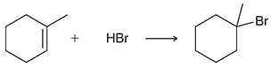

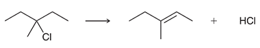

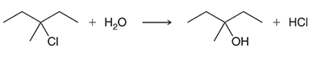

- identify electrophilic and/or nucleophilic center or each of the following as a nucleophile or electrophile, and identify the reactive site in each:
- For each of the following reactions identify the arrow-pushing pattern that is being utilized, compare reversible vs irreversible:

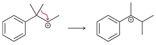

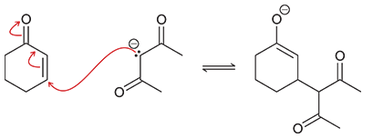

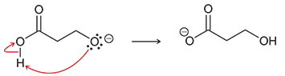

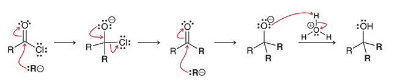

- Rank the three carbocations shown in terms of increasing stability:

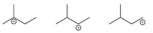

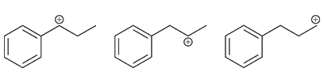

# **Lesson-11,12**

# [**Lesson-11 (ch-07)**](https://drive.google.com/file/d/112GSpcobX8xefKN-QIAUBLo0mFouu21i/view?usp=sharing)

## ⏣ *Aliphatic Substitution S<sub>N</sub>1, S<sub>N</sub>2, Reaction-Mechanism & Stereochemistry*

- **Alkylhalids**: know how to name alkylhalids. know how to identify primary, secondary and tertiary alkylhalide.
- **Substitution and Elimination Reaction**: what is nucleophilic aliphatic substitution reaction and elimination reactions and the mechanisms overview.
- **Substitution Reaction Mechanism**: know the mechanism of S<sub>N</sub>1 (unimolecular nucleophilic substitution reaction) and S<sub>N</sub>2 (Bimolecular nucleophilic substitution reaction). Understand how to draw pushing arrow for these reactions and Stereospecificity of SN2 reactions.
- **Substituion Reaction Product**: know how to differentiate S<sub>N</sub>1 (unimolecular nucleophilic substitution reaction) and S<sub>N</sub>2 (Bimolecular nucleophilic substitution reaction).

  > in terms of rate of reaction, nucleophilic strength, Stereochemistry, Stereospecificity, effect on structure of activity, and solvation (protic vs aprotic). know when proton transfer is essential for S<sub>N</sub>1 vs S<sub>N</sub>2 and why vinyl and aryl halides do not react either S<sub>N</sub>1 or SN2. know why cycloalkane halide favor undergo S<sub>N</sub>1 (NOT S<sub>N</sub>2).

### 🍓🍓**Concept Check and/or Mastering the Modality**

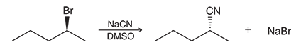

(a) Determine whether this reaction proceeds via an S<sub>N</sub>2 or S<sub>N</sub>1 process, and draw a complete mechanism. (b) What is the expected rate equation for this process? (c) Would the process occur at a faster rate if the concentration of cyanide was doubled? (d) Draw an energy diagram for this process.

(S)-2-Chloropentane and NaSH; 1-Bromopentane and KOH

# [**Lesson-12 (ch-07)**](https://drive.google.com/file/d/1GjcUnEWS5lh_uw8o43CHmw1IDJUAdTsE/view?usp=sharing)

## ⏣ *Elimination Reaction E1/ E2, Reaction-Mechanism & Stereochemistry*

- **Alkene**: understand how to name alkene and stereoisomerism of alkene( *cis*-, *trans*-, *E*-, *Z*- ).
- **Alkene Stability**: know how to identify stable alkene.
- **Elimination Reaction Mechanism and Product**: know how to draw the mechanism for Bimolecular elimination (E2) and monomolecular elimination (E1) reaction.

> Understand regioselectivity and stereoselectivity of E2 and E1 reaction. understand Zaitsev product vs Hofman product (regeoselectivity), understand stereochemistry, stereoselectivity and stereospecificity. how to differentiate E2 vs E1.

### ⏣ *S<sub>N</sub>1/E1, S<sub>N</sub>2/E2, synthesis & retrosynthetic analysis*

- **Substitution Vs Elimination and Retrosysnthetic analysis**:
> - Be able to differentiate to compare reaction pathway through S<sub>N</sub>1 vs S<sub>N</sub>2 and draw the mechanisms and energy diagrams (concerted process vs step-by-step process).
> - understand how to differentiate S<sub>N</sub>2 vs E2, S<sub>N</sub>1 Vs E1 and how predicts substitution vs elimination.
> - Synthesis strategies and Retrosynthetic analysis.

### 🍓🍓**Concept Check and/or Mastering the Modality**

- IUPAC name of the following alkene and identify which alkene most and least substituted, and and arrange each set of isomeric alkenes in order of stability.

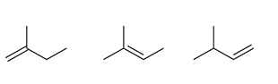

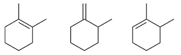

- For each synthesis below, provide a suitable **starting material (an alkyl halide or an alcohol)**; *Or*, Predict the **major product (Zaitsev/Hofman)** for each of the following reactions; *Or*, Each of the following compounds can be prepared from an alkyl iodide and a suitable nucleophile. In each case, identify the **alkyl iodide and the nucleophile** that you would use; *Or*, Identify the missing reagent(s) for each of the following transformations. **In each cases IUPAC name the Product** and if the product is alkene designate *cis-*/*trans-* or *E-*/*Z-*.

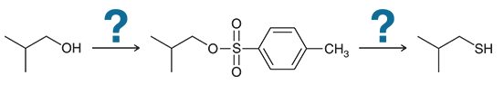

- Consider following reaction:

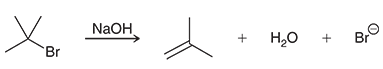

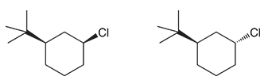

- Predict the major and minor products for each of the following reactions if not provided. Draw curved arrow a plausible mechanism and energy diagram for each of the following transformations with possible explanation major *vs* minor product.

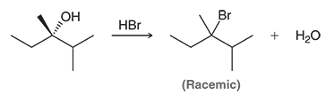

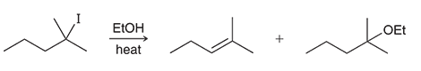

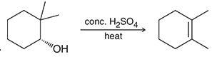

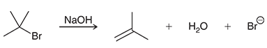

# [**Lesson-13 (ch-08)**](https://drive.google.com/file/d/1x2uZF9GiEKRqYwbExkCKtSnNugpmSe-7/view?usp=sharing)

## ⏣ *Addition Reaction of Alkenes*

- Know IUPAC naming of alkene and understand **electrophilic addition reaction of alkene (C=C) is an acid-base kind of reaction where alkene act as a base and/or nucleophile**.
- Understand following reaction of alkenes (i to viii) and mechanism (drawing curved arrow).

(i) hydrohalogenation (regeoselectivity, stereochemistry).

> regeochemical (Markovnikov/anti-Markovnikov)

(ii) halohydrin.  
(iii) hydration.

> oxymercuration-demercuration; hydroboration-oxidation (regeoselectivity, stereospecificty)

(vi) catalytic hydrogenation (symmetric vs assymetric, stereochemistry).  
(v) halogenation.

> Know the stereochemistry of addition of halogen to alkene (whether syn- and/or anti- addition). Understand how to compare anti- bromine addition reaction of cis-butene and trans-butene such as racemic vs meso product.

(vi) dihydroxylation (anti, syn). (vii) ozonolysis  
(viii) hydrogenetation.

> Know homogeneous and heterogeneous catalyst (stereospecificity). Understand syn- and anti- addition reaction. Be able to compare between *syn*- and *trans*- or *anti*- addition reaction, asymmetric catalytic hydrogenation.
- Know how to determine regeoselective, stereoselective, stereospecific reaction and product(s).
- Synthesis strategies: understand changing the position of leaving group and pi-bond in the product.

### 🍓🍓**Concept Check and/or Mastering the Modality**

- Provide a IUPAC (systematic) name for each of the following compounds, and/or Draw a bond-line structure for each of the following compounds. Classify each of the following alkenes as monosubstituted, disubstituted, trisubstituted, or tetrasubstituted

3-Isopropyl-2,4-dimethyl-2-pentene; 1,2-Dimethylcyclobutene

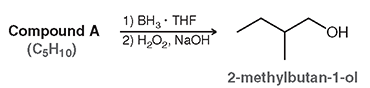

- Draw the expected major product for each of the following reactions, In cases where the reaction produces a new chiral center, be sure to draw both enantiomers.
- Identify the structure of starting alkene in each of the following cases. or In each of the following, identify the alkene that would yield the given product(s) via ozonolysis
- Identify the reagents that you would use to achieve each of the following transformations.
- Suggest an efficient synthesis for each of the following transformations.

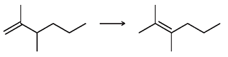

# [**Lesson-14 (ch-09)**](https://drive.google.com/file/d/1AIEYABpMRNWGDS05GK5FG1kDQJdsowNS/view?usp=sharing)

## ⏣ *Addition Reaction to Alkyne*

- **IUPAC Naming Alkyne**: Know IUPAC and common naming of alkyne, and Understand to identify terminal alkyne / internal alkyne.
- **Preparation of Alkyne**: Know dehydrohalogenation of alkyl halide, metal acetylides reaction with primary alkyl halide to prepare alkyne.
- **Alkyne reaction and mechanism**: Understand following reaction of alkyne and reaction mechanism.

(i) reduction (hydrogenation with Pt, Na and NH3, Lindlar catalyst).  
(ii) hydrohalogenation (one or two mole / excess).  
(iii) Hydration (keto-enol tautomerism).

> controling regeiochemistry of alkyne hydration.

(iv) hydroboration-oxidation.  
(v) Halogenation (excess / one equivalent).

> cataltic hydrogenation vs. dissolving metal reduction.

(vi) ozonolysis of alkyne.

- **Physical properties of Alkyne**: Know acidity and properties of acetylene and terminal alkynes. understand how terminal alkyne act as an acid.
- **Terminal Alkylation**: know the alkylation of terminal alkyne.
- review of reaction and synthesis strategies of C,C triple bond.

### 🍓🍓**Concept Check and/or Mastering the Modality**

- identify following as termnal or internal alkyne. Provide the systematic name for each of the following or draw a bond-line structure for each of the following compounds. Draw the major product expected when each of the following alkynes is treated with (i) sodium metal in liquid ammonia, (ii) O<sub>3</sub> followed by water:

4,4-Dimethyl-2-pentyne; (*Z*)-3-isopropylpent-3-en-1-yne

- For each of the following transformations, predict the major or final product and draw a mechanism for its formation.

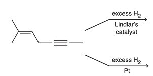

- Identify reagents that can be used to acheive each of the following transformations.

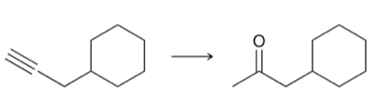

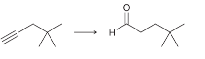

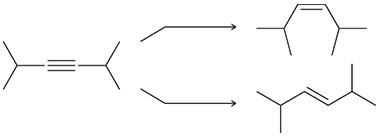

- Propose an efficient synthesis for each of the following transformations.

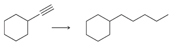

- determine which of the following bases are suitable for the deprotonation of a terminal alkyne, and explain your choices:

(a) NaOCH<sub>3</sub> (b) NaH (c) BuLi (d) NaOH (e) NaNH<sub>2</sub>

- Compound A undergoes an addition reaction with molecular bromine to give compound B. Diphenylacetylene (shown below) is produced when compound B is treated with an excess of sodium amide in ammonia. Ignoring stereochemistry, provide structures for compounds A and B.

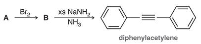

- Draw the structures of compounds A–D:

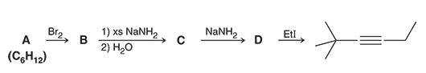